# Modelling pipeline for prediction of early Tecfidera discontinuation

Lachlan McLachlan; lachlan.mclachlan@iqvia.com

1st December 2017

## Introduction

Biogen has engaged with [IQVIA](https://www.iqvia.com) to build a predictive model to identify patients initiated on Tecfidera who at risk of early discontinuation.

The following notebook provides a pipeline for building such a model, starting with a clean dataset, producing visual representations of the data, building a predictive model, evaluating model performance, and augmenting the model with clinical insight.

While effort has been made to ensure this material is accessible to an informed lay-audience, it assumes the reader is familiar with techniques such as cross-validation, parameter tuning, decision trees, and the R language.

Links to relevant material are provided where available.

### Load in relevant libraries and functions

If these are yet to be installed, please run:

```r
install.packages(c("mlr", "tidyverse", "xgboost", "Ckmeans.1d.dp", "data.table"))
```

…else run the following:

```r
library(mlr)
library(tidyverse)
library(xgboost)
```

Please define a directory from which to load the data, predictor descriptions and the weights for the Bayesian analysis. Please also source the functions which are required to run this notebook (called *“Biogen_modelling_functions.R”*):

```r
set_wd <- "F:/Lachlan/biogen_tecfidera/code_deliverable/"
data_dir <- "F:/Projects/Biogen_Tecfidera/Data/Processed/data_model_3_for_hyperparam_search_LM/"
source("Biogen_modelling_functions.R")
```

### Load in the dataset and descriptions file

```r
descriptions <- paste0(data_dir, "predictor_descriptions.csv") %>%  read_csv()
```

### Plotting distributions

It is useful from both a quality control and data exploration perspective to plot some distibutions over variables of interest.

We’ll split these distributions by the two classes of the outcome variable *(i.e one density plot for positives and one for negatives on the same plot)*. This enables us to look for obvious points our model might exploit when distinguishing between the two outcome classes.

```r
# density plot split by outcome variable for number of days between initiation
# and first lab/radiology event.
ggplot(raw_data, aes(post_lab_radio_date_fst_diff, group=as.factor(discontinue_flg_1_0), fill=as.factor(discontinue_flg_1_0))) +
     geom_density(alpha = .2, kernel = "gaussian") +
  xlab( 'Number of days following Tecfidera initiation before first lab/radiology event' )

# density plot split by outcome variable for number of days between initiation
# and first lab/radiology event.
ggplot(raw_data, aes(post_symps_fst3_diff, group=as.factor(discontinue_flg_1_0), fill=as.factor(discontinue_flg_1_0))) +
     geom_density(alpha = .2, kernel = "gaussian") +
  xlab( 'Number of days following Tecfidera initiation
        before first fatigue/malaise event' )
```

[output not shown]

## Modelling

#### Create a machine learning classification task and an XGBoost learner:

We have selected [XGBoost](http://xgboost.readthedocs.io/en/latest/) as our algorithim of choice (having explored other options and found it to be best suited to the task)

```r
# extract patient ids and set to null
id <- raw_data$pat_id
raw_data$pat_id <- NULL
# convert outcome variable to factor and rename as 'label'
model_data <- raw_data %>% mutate(discontinue_flg_1_0 = as.factor(discontinue_flg_1_0)) %>%
  rename(label = discontinue_flg_1_0)
# create machine learning task
dataset <- makeClassifTask(id = "Data for HP search", data = model_data,
                           target = "label", positive = 1)
# create XGBOOST learner
lrn_xgb <- makeLearner(cl = "classif.xgboost", predict.type = "prob")
lrn_xgb$par.vals <- list(nrounds = 100,
                         verbose = FALSE,
                         objective = "binary:logistic")
```

#### Tune Hyperparameters

*more information on XGBoost’s hyperparameters can be found [here](http://xgboost.readthedocs.io/en/latest/parameter.html)*

##### 1: Construct a set of hyperparameters to tune:

```r
# construct the set of hyperparameters over which to search:
ps <- makeParamSet(
  makeNumericParam("eta", lower=0.01, upper=0.3),
  makeIntegerParam("max_depth", lower=2, upper=6),
  makeIntegerParam("min_child_weight", lower=1, upper=5),
  makeNumericParam("colsample_bytree", lower=.5, upper=1),
  makeNumericParam("subsample", lower=.5, upper=1)
)
```

##### 2: Tune hyperparameters using a 5 fold cross validation:

```r
# make cross validation description
rdesc <- makeResampleDesc(method = "CV", iters = 5, predict = "test")

# make random search iteration:
ctrl <- makeTuneControlRandom(maxit = 200)

# tune parameters (maximising auc):
res_tune <- tuneParams(learner = lrn_xgb, task = dataset, resampling = rdesc,
                        par.set = ps, control = ctrl,
                       measures = list(auc, mmce))
```

##### 3: Create a learner with these optimised hyperparameters

```r
lrn_xgb_opt <- setHyperPars(lrn_xgb, par.vals = res_tune$x)
```

#### Cross validate the optimised learner and evaluate performance.

*Note: Ideally one would test the set of optimal hyperparameters on a previously unseen dataset. However, given that the project is in phase 1, in which the model is not deployed on a wider population of patients, we have decided to retain as much signal as possible during the model fitting. Therefore for the time being the same dataset on which the hyperparameters were selected is being used to evaluate performance. This may lead to optimistic estimates of performance. Using an unseen dataset for testing in the future could help alleviate this issue.*

```r
# run cross validation with tuned learner to estimate performance
res_opt <- resample(learner = lrn_xgb_opt,
                    task = dataset,
                    resampling = rdesc, measures = list(auc, mmce))

# add patient_id to resample predictions
res_opt$pred$data$pat_id <- id[res_opt$pred$data$id]
```

Evaluate performance for each fold of the cross validation. *Further information on performance metrics in the mlr package can be found [here](https://mlr-org.github.io/mlr-tutorial/release/html/performance/index.html)*

```r
# evaluate performance
print(res_opt$measures.test)
```

| iter | auc | mmce |
| --- | --- | --- |
| 1 | 0.8843634 | 0.1479547 |
| 2 | 0.8898756 | 0.1489547 |
| 3 | 0.8978822 | 0.1385017 |
| 4 | 0.8948888 | 0.1488251 |
| 5 | 0.8856065 | 0.1524390 |

#### Train a single model

The idea is to train a single XGBoost over all the available data.  
This allows for the evaluation of predictor importance.

##### 1: Train an xgboost on the dataset

```r
xgb_model <- train(learner = lrn_xgb_opt, task = dataset)
```

##### 2: Evaluate [predictor importance](http://xgboost.readthedocs.io/en/latest/R-package/discoverYourData.html#feature-importance)

```r
# overall importance:
importance <- xgb.importance(feature_names = xgb_model$features,
                                   model = xgb_model$learner.model)

# run detailed importance (requires conversion of data to numeric matrix):
detailed_imp <- xgb.importance(feature_names = xgb_model$features,
                               model = xgb_model$learner.model,
                               data = as.matrix(sapply(dataset$env$data,
                                                       function(x) as.numeric(as.character(x)))),
                               label = as.numeric(dataset$env$data$label))

# join these importance tables to desciptions of predictors
importance <- left_join(importance, descriptions, by = "Feature")
detailed_imp <- left_join(detailed_imp, descriptions, by = "Feature")

print(importance[1:5,c(1,2,6)])
```

[output not shown]

##### 3: Plot predictor importance

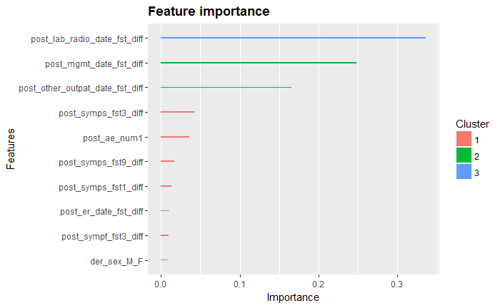

```r
xgb.ggplot.importance(importance_matrix = data.table(importance),
                      top_n = 10, rel_to_first = FALSE, n_clusters = 3)
```

### Integrating clinical insights using a Bayesian approach

This process takes in a set of nine predictors which are assumed to be clinically meaningful by domain experts but which are too sparsely populated in the data to be used by XGBoost. It estimates a log likelihood for each of these variables. These log likelihoods are then weighted and combined with the original XGBoost model. The performance of the combined model is then checked against the performance of the original XGBoost model. It is expected that the inclusion of these clinical insights will result in a very small reduction in AUC.

The process is as follows:

1. A likelihood function is estimated for each variable (i.e. the density function of each variable for each value of the outcome)
2. A log-likelihood ratio (logit) is computed for each variable.
3. The value of the logit for each variable is then weighted according to the weights provided by clinicians.
4. A weighted sum is then computed over each logit and the logit of the original XGBoost model score to produce a single vector of combined scores.
- All weights are coerced such that they sum to 1 but retain their order- this overcomes the difficulties faced when a patient presents with only a subset of the above variables.
- A minimum weight is assigned to the original XGBoost model. This weight is then allowed to take a larger value in order to ensure all weights sum to 1.
5. The new vector of combined scores can then be used in place of the vector of risk scores output by the original XGBoost, and model performance can be estimated.

#### Before modelling:

Extract the names of the features to be modelled using the Bayesian technique and assign a minimum weight to the XGBoost model (see comment for explanation of minimum weight):

```r
# View the weights dataframe
print(weights_df)

# extract the set of variables of interest
bayes_vars <- weights_df$feature

# Define the minimum model weight. This is the minimum amount of confidence
# the user has in the predictions from the xgboost model, relative to those from the
# bayesian approach. In order to balance the influence of the model while
# preserving the input from the Bayesian approach, we
# recommend a min_model_weight of 0.5:
min_model_weight <- 0.5
```

[output not shown]

#### Step 1

Estimate a likelihood function based on more densely populated features.

- The idea is to generate a baseline distribution for the data, which can be used when a more specific distriution can’t be estimated.

```r
# extract some date difference "diff" features from the 50 most important features
data_extract <- raw_data %>% select_(.dots = importance$Feature[1:50]) %>%  select(contains("diff"))

# stack these densely populated variables on top of each other
data_stack <- data.frame(stack(data_extract),
                             label = rep(dataset$env$data$label,
                                         ncol(data_extract)))

# remove missing values
data_stack <- data_stack[!is.na(data_stack$values), ]

# compute a likelihood function for these stacked variables
model_prior = train_bayes(data_stack$values, data_stack$label, model__prior = NULL)
```

#### Step 2

Extract the nine “Bayesian” variables from the dataset.

```r
# extract bayes features from dataset:
bayes_data <- select_(model_data, .dots = c(bayes_vars, "label"))
```

#### Step 3

Generate a set of logit scores using cross validation:

- Using 3 fold cross validation, first estimate likelihood functions for the training fold (one for each class) using kernel density estimation.
- Feed the test fold through these functions to output a set of likelihood values.
- Convert the likelihoods into a single ‘logit’ score (log-likelihood ratio).
- The result is a logit score for each patient in the dataset for each of the nine ‘Bayesian’ features.

```r
bayes_logit_preds <- bayes_data %>% select(-label) %>%
  lapply( function(feature,
                   label = bayes_data$label,
                   model_prior = model_prior, k = 3) {

  # create dataframe of label and feature
  cv_data <- data.frame(label = label, feature = feature)

  # assign each observation to one of k groups for cross validation
  cv_data$fold <- dismo::kfold(x = cv_data, k = k)

  # define a column of zeros to be populated with predictions
  cv_data$logit_scores <- NA

  # for each of these k groups, train a classifier on all other data, then
  # use it to predict for group m:

  for(m in 1:k) {

    # define the training set
    train_set <- cv_data[cv_data$fold != m, ]

    # remove missin values
    train_set <- train_set[!is.na(train_set$feature),]

    # define the prediction_set
    pred_set <- cv_data[cv_data$fold == m, ]

    # train classifier using training set
    train_cv <- train_bayes(feature = train_set$feature, label = train_set$label,
                            model__prior = model__prior)

    # predict on test set
    pred_cv <- predict_bayes_logit(model = train_cv, feature = pred_set$feature)

    # populate cv_data with predictions
    cv_data$logit_scores[cv_data$fold == m] <- pred_cv

  }

  # returns a list of logit scores from each outer fold of the cross validation
  return(cv_data$logit_scores)

})

# combine with patient id and label into one dataframe
bayes_logit_preds <- data.frame(label = bayes_data$label,
                             pat_id = id,
                             bayes_logit_preds)
```

#### Step 4

Compute a weighted sum of the logit scores and the original score from the XGBoost model.

- The idea is to multiply the each of the nine vectors of logit scores by a weight provided by clinicians.
- These weighted logit scores are combined with the original score from the XGBoost model via a weighted sum.
- The output is a single ‘combined’ logit score, which can be used in place of the original score from the XGBoost.

```r
# extract prediction object
predictions <- res_opt$pred

# convert XGBoost scores to logits
predictions$data$xgb_logit <- logit_transform(predictions$data$prob.1)

# join XGBoost's predictions onto the Bayesian predictions
pred_join <- inner_join(bayes_logit_preds, select(predictions$data, pat_id, xgb_logit), by = "pat_id")

# ensure pred_join has correct column classes otherwise combining logits
# will not work:
pred_join[,3:ncol(pred_join)] <- sapply(pred_join[,3:ncol(pred_join)],
                                        function(x) { as.numeric(as.character(x)) })

# combine the logit scores to produce one score (please ignore warnings):
logits_combined <- combine_logits(input_data = pred_join,
                                  weights = weights_df,
                                  min_model_weight = min_model_weight,
                                  model_logit_column = "xgb_logit")
```

#### Step 5

Check performance of combined model to ensure the auc has not reduced significantly

```r
# replace predictions contents of predictions object with results from
# combined model
combined_pred <- predictions
combined_pred$data$prob.1 <- logits_combined$sum_weighted_logit
combined_pred$data$truth <- pred_join$label
combined_pred$data$pat_id <- logits_combined$pat_id
combined_pred$data[c("iter", "response", "set", "xgb_logit", "id", "prob.0")] <- NULL

# compute auc for combined model. It should show no significant change
# from the auc in the original model.
performance(pred = combined_pred, measures = auc)

# compare this to the performance of the original XGBoost model
res_opt$aggr[1]

# The auc may for the Bayesian model be marginally lower than the pure XGBoost model;
# However it should not be significantly lower since the Bayesian model
# only affects 230 patients.
```

[output not shown]

*For information about the methods deployed in this Notebook, please contact the author.*